# Shopify Technical Challenge

Silvane Paixao (silpai)

2021-09-15

## Question 1

The Average Order Value (AOV) is the average $ spent each time a customer places an order. It is calculated using the total revenue by the total number of customers’ orders. Validating the AOV stated in the challenge instructions for the existing 30 days, it was confirmed that the monthly AOV is $3145.

**Table 1** shows the daily AOV, delta = daily AOV - monthly AOV and its delta classification.

| created_date | order_day | order_amount_day | daily_AOV | AOV30d | delta | margin |
| --- | --- | --- | --- | --- | --- | --- |
| 2017-03-01 | 182 | 106154 | 583 | 3145 | -2562 | below monthly AOV |
| 2017-03-02 | 182 | 1588109 | 8726 | 3145 | 5581 | above monthly AOV |
| 2017-03-03 | 162 | 48729 | 301 | 3145 | -2844 | below monthly AOV |
| 2017-03-04 | 165 | 855504 | 5185 | 3145 | 2040 | above monthly AOV |
| 2017-03-05 | 163 | 126293 | 775 | 3145 | -2370 | below monthly AOV |
| 2017-03-06 | 148 | 42266 | 286 | 3145 | -2860 | below monthly AOV |
| 2017-03-07 | 196 | 1465850 | 7479 | 3145 | 4334 | above monthly AOV |
| 2017-03-08 | 156 | 43432 | 278 | 3145 | -2867 | below monthly AOV |
| 2017-03-09 | 199 | 191287 | 961 | 3145 | -2184 | below monthly AOV |
| 2017-03-10 | 167 | 48908 | 293 | 3145 | -2852 | below monthly AOV |
| 2017-03-11 | 167 | 781305 | 4678 | 3145 | 1533 | above monthly AOV |
| 2017-03-12 | 159 | 856797 | 5389 | 3145 | 2244 | above monthly AOV |
| 2017-03-13 | 159 | 51362 | 323 | 3145 | -2822 | below monthly AOV |
| 2017-03-14 | 148 | 122336 | 827 | 3145 | -2319 | below monthly AOV |
| 2017-03-15 | 143 | 795442 | 5563 | 3145 | 2417 | above monthly AOV |
| 2017-03-16 | 143 | 350442 | 2451 | 3145 | -694 | below monthly AOV |
| 2017-03-17 | 198 | 915709 | 4625 | 3145 | 1480 | above monthly AOV |
| 2017-03-18 | 173 | 259864 | 1502 | 3145 | -1643 | below monthly AOV |
| 2017-03-19 | 149 | 773732 | 5193 | 3145 | 2048 | above monthly AOV |
| 2017-03-20 | 158 | 98665 | 624 | 3145 | -2521 | below monthly AOV |
| 2017-03-21 | 179 | 101563 | 567 | 3145 | -2578 | below monthly AOV |
| 2017-03-22 | 175 | 857995 | 4903 | 3145 | 1758 | above monthly AOV |
| 2017-03-23 | 152 | 50003 | 329 | 3145 | -2816 | below monthly AOV |
| 2017-03-24 | 155 | 1456430 | 9396 | 3145 | 6251 | above monthly AOV |
| 2017-03-25 | 170 | 857247 | 5043 | 3145 | 1898 | above monthly AOV |
| 2017-03-26 | 175 | 207534 | 1186 | 3145 | -1959 | below monthly AOV |
| 2017-03-27 | 170 | 334819 | 1970 | 3145 | -1176 | below monthly AOV |
| 2017-03-28 | 175 | 2165019 | 12372 | 3145 | 9226 | above monthly AOV |
| 2017-03-29 | 165 | 98929 | 600 | 3145 | -2546 | below monthly AOV |
| 2017-03-30 | 167 | 73915 | 443 | 3145 | -2703 | below monthly AOV |

Considering the margin data from **Table 1**, it can be seen at **Table 2** that 40% of the days had revenue above of the the monthly AOV ($3145).

| Var1 | Freq | Prop |
| --- | --- | --- |
| above monthly AOV | 12 | 0.4 |
| below monthly AOV | 18 | 0.6 |

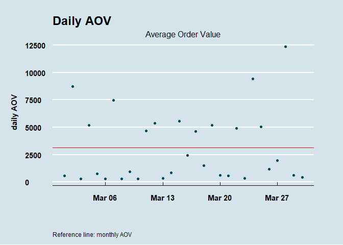

```r
dailyAOV<- TAB_montly_AOV %>%
  ggplot(aes(x=created_date, y=daily_AOV))+
  geom_point(col='#014d64')+
  labs(x='', y='daily AOV')+
  theme_economist()+
  labs(title = 'Daily AOV',
       subtitle= "Average Order Value",
       caption='Reference line: monthly AOV'
  )+
  geom_hline(yintercept=AOV_30d,color='#e5001f',lwd=0.4)+
  theme(plot.title = element_text(family = 'Avenir Next Condensed', hjust=0,size=18,margin=margin(-7,0,10,0)),
        plot.subtitle = element_text(family = 'Avenir Next Condensed',size=12, margin=margin(-5,-1,3,0)),
        plot.caption = element_text(family = 'Avenir Next Condensed', size=9, hjust = 0,margin=margin(34,0,-45,0)),
        axis.text = element_text(face='bold'),
        axis.title.x = element_text(family = 'Avenir Next Condensed',face = 'bold', margin=margin(12,0,-12,0)),
        axis.title.y = element_text(family = 'Avenir Next Condensed',face = 'bold', margin=margin(0,12,0,0)),
        plot.margin = margin(1,1.5,2,0.5, 'cm'))
dailyAOV
```

Comparing *Daily AOV - Monthly AOV*, the maximum daily margin gain was $9226 and the maximum daily margin lost was $-2867.

```
##    Min. 1st Qu.  Median    Mean 3rd Qu.    Max.
##   -2867   -2574   -1801     -50    2004    9226
```

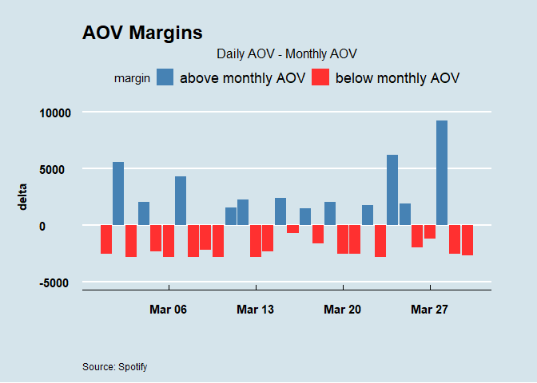

```r
daily_margin<- TAB_montly_AOV %>%
  ggplot(aes(x=created_date,y=delta))+
  geom_bar(stat="identity", position="identity", aes(fill=margin)) +
  labs(x='', y="delta")+
  theme_economist()+
  labs(title = 'AOV Margins',
       subtitle= "Daily AOV - Monthly AOV",
       caption='Source: Spotify'
  )+

  scale_fill_manual(values=c("steelblue","firebrick1")) +

  theme(plot.title = element_text(family = 'Avenir Next Condensed', hjust=0,size=18,margin=margin(-7,0,10,0)),
        plot.subtitle = element_text(family = 'Avenir Next Condensed',size=12, margin=margin(-5,-1,3,0)),
        plot.caption = element_text(family = 'Avenir Next Condensed', size=9, hjust = 0,margin=margin(34,0,-45,0)),
        axis.text = element_text(face='bold'),
        axis.title.x = element_text(family = 'Avenir Next Condensed',face = 'bold', margin=margin(12,0,-12,0)),
        axis.title.y = element_text(family = 'Avenir Next Condensed',face = 'bold', margin=margin(0,12,0,0)),
        plot.margin = margin(1,1.5,2,0.5, 'cm')) +
  ylim(-5000,10000)
daily_margin
```

**Loyalty Analysis - Metric to report**

Calculation of the **Purchase Frequency** indicated that a customer purchased 16.6 times in march (see **Table 3**:*number of orders = 5000*, *number of unique user=301*).

| month | orders_count | user_count | Purchase_Freq |
| --- | --- | --- | --- |
| Mar | 5000 | 301 | 17 |

Looking at the data, I was curious to know if customers were loyal to a particular store. **Table 4** shows the number of times a user ordered at the same store and AOV per user per store.

Customers shopped in multiple stores (except for user 607, who only shopped at store 42 for 17 times).

|  | user_id | shop_id | orders_count | order_amount_sum | AOV_user_shop | user_shop_class |
| --- | --- | --- | --- | --- | --- | --- |
| 1 | 607 | 42 | 17 | 11968000 | 704000 | A: Above 2x Monthly AOV |
| 2 | 700 | 2 | 1 | 188 | 188 | C: less than monthly AOV |
| 3 | 700 | 4 | 1 | 384 | 384 | C: less than monthly AOV |
| 4 | 700 | 11 | 1 | 184 | 184 | C: less than monthly AOV |
| 5 | 700 | 34 | 1 | 122 | 122 | C: less than monthly AOV |
| 6 | 700 | 37 | 1 | 284 | 284 | C: less than monthly AOV |
| 7 | 700 | 38 | 1 | 570 | 570 | C: less than monthly AOV |
| 8 | 700 | 39 | 1 | 268 | 268 | C: less than monthly AOV |
| 9 | 700 | 46 | 1 | 166 | 166 | C: less than monthly AOV |
| 10 | 700 | 50 | 1 | 579 | 579 | C: less than monthly AOV |

[output cut: 4587 more lines]

Considering that each user shopped in multiple locations, **Table 5** shows that 99% AOV user per store (4551 stores) were classified as class C: less than monthly AOV, and the 1% (46 stores) were class A: Above 2x Monthly AOV.

| Var1 | Freq | Prop |
| --- | --- | --- |
| A: Above 2x Monthly AOV | 46 | 0.01 |
| C: less than monthly AOV | 4551 | 0.99 |

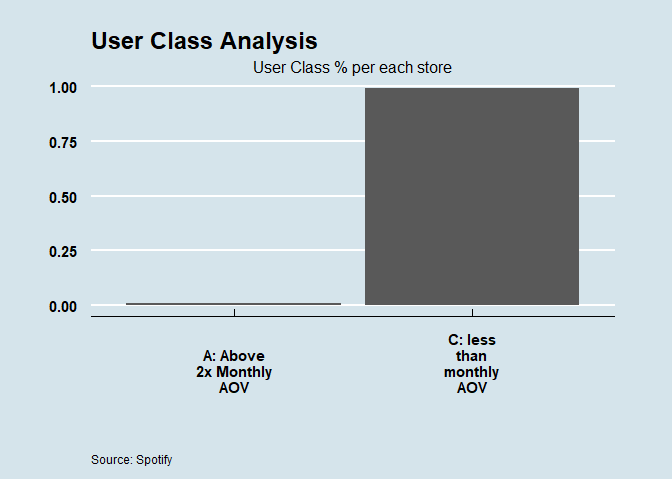

**Table 6** displays the number of stores that each user ordered.

|  | user_id | shop_id_count | order_amount_ALL_sum | AOV_user_ALL_shop | user_ALL_shop_class |
| --- | --- | --- | --- | --- | --- |
| 1 | 607 | 1 | 11968000 | 11968000 | A: Above 2x Monthly AOV |
| 2 | 717 | 6 | 2337 | 389.5 | C: less than monthly AOV |
| 3 | 750 | 6 | 2359 | 393.166666666667 | C: less than monthly AOV |
| 4 | 719 | 9 | 2314 | 257.111111111111 | C: less than monthly AOV |
| 5 | 766 | 9 | 80076 | 8897.33333333333 | A: Above 2x Monthly AOV |
| 6 | 802 | 9 | 3696 | 410.666666666667 | C: less than monthly AOV |
| 7 | 806 | 9 | 2572 | 285.777777777778 | C: less than monthly AOV |
| 8 | 812 | 9 | 27827 | 3091.88888888889 | C: less than monthly AOV |
| 9 | 833 | 9 | 3809 | 423.222222222222 | C: less than monthly AOV |
| 10 | 902 | 9 | 2108 | 234.222222222222 | C: less than monthly AOV |

[output cut: 291 more lines]

Considering the 301 unique users, Table 7 indicates that the majority of individual customers (92%) have been being classified as C: less than monthly AOV, followed by 7% who spent between the monthly AOV and 2x monthly AOV. Only 1% of the customers were A: above 2x monthly AOV; they should be treated as VIP.

| Var1 | Freq | Prop |
| --- | --- | --- |
| A: Above 2x Monthly AOV | 4 | 0.013 |
| B: >= monthly AOV <= 2x Monthly AOV | 20 | 0.066 |
| C: less than monthly AOV | 277 | 0.920 |

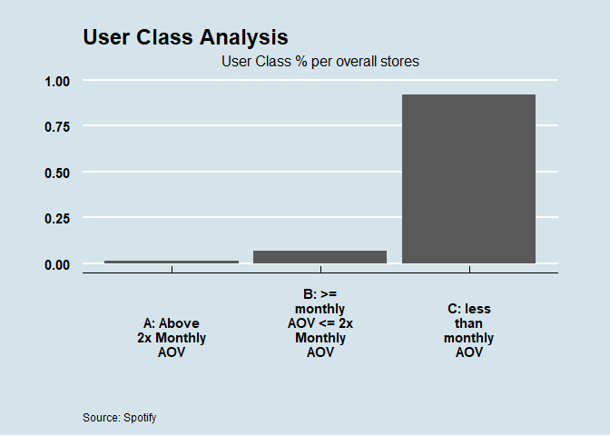

## Question 2 - SQL

**1) How many orders were shipped by Speedy Express in total?**

SELECT sh.ShipperName , COUNT(sh.ShipperName) AS ShipperCount  
FROM Orders o  
INNER JOIN Shippers sh ON  
sh.ShipperID= o.ShipperID  
WHERE sh.ShipperName=‘Speedy Express’;

| ShipperName | ShipperCount |
| --- | --- |
| Speedy Express | 54 |

**2) What is the last name of the employee with the most orders?**

SELECT e.LastName, COUNT(od.OrderID) AS OrderCount  
FROM Orders o  
INNER JOIN Employees e ON  
e.EmployeeID= o.EmployeeID  
INNER JOIN OrderDetails od ON  
od.OrderID= o.OrderID  
GROUP BY e.LastName  
ORDER BY OrderCount DESC  
LIMIT 3;

| LastName | OrderCount |
| --- | --- |
| Peacock | 123 |
| Davolio | 78 |
| Leverling | 74 |

**3) What product was ordered the most by customers in Germany?**

SELECT p.ProductName, cus.Country, od.Quantity  
FROM Orders o  
INNER JOIN OrderDetails od ON  
od.OrderID= o.OrderID  
INNER JOIN Products p ON  
p.ProductID= od.ProductID  
INNER JOIN Customers cus ON  
cus.CustomerID= o.CustomerID  
WHERE Country = ‘Germany’  
GROUP BY p.ProductName  
order by Quantity DESC  
LIMIT 3;

| ProductName | Country | Quantity |
| --- | --- | --- |
| Steeleye Stout | Germany | 100 |
| Teatime Chocolate Biscuits | Germany | 80 |
| Raclette Courdavault | Germany | 70 |